# AuxTel Focus Study - 20-Dec-21

Craig Lage - 20-Dec-21

In this notebook, investigate focus settings vs elevation and temperature on observations between 08-Sep21 and 04-Nov-21. The goal is to reduce the spread in focus settings vs elevation by compensating for temperature.

```python
import sys, time, os, asyncio

from datetime import datetime
import numpy as np
import matplotlib.pyplot as plt
import pandas as pd
from astropy.time import Time, TimeDelta
from lsst.daf.butler import Butler
```

```python
# Get EFD client and butler
from lsst_efd_client import EfdClient
client = EfdClient('ldf_stable_efd')
butler = Butler('/repo/main', collections="LATISS/raw/all")
```

### Get the data

The cell below gathers the data from the nights of observations. Images (expIds) were manually selected from the nights with two criteria:

(1) They need to be after the M1 pressure was adjusted (about mid August) to reduce mirror "sliding"

(2) They need to be images immediately after the focus was determined through the CWFS process.

```python
before = 15.0
temp_before = 60.0

els = []
offs = []
poss = []
temp_airs = []
temp_trusss = []
temp_m2s = []
temp_exts = []
filt = []
user = []

filename = '/project/cslage/AuxTel/efd_temp/EFD_Temp_Full_08Dec21.txt'
outfile = open(filename, 'w')
outfile.write(f"expId\t\tElev\t\tOff_disp\tOff_filt\tOff_user\tOff_tot\
                \t\tHex_z\t\tT_air\tT_truss\tT_M2\tT_ext\tW_spd\tW_dir\
                \tDIMM\n")

# Below are the selected observations
dayObss = [20210908, 20210909, 20211005, 20211006, 20211102, 20211103, 20211104]
seqNos = [[128, 134, 145, 149, 153, 161, 165, 489, 614, 641, 793], \
          [152, 243, 348, 470, 542, 674, 773, 800], \
          [ 297, 302, 307, 310, 316, 398, 415, 422, 662], \
          [146, 545, 552], [93, 333, 346, 351, 374, 377, 383, 399, 498, 567], \
         [70, 161, 176, 288, 446, 551, 621], \
          [186, 253, 280, 298, 362, 383, 412, 581, 613, 942, 949, 960]]
for n, dayObs in enumerate(dayObss):
    if dayObs < 20211013:
        # EFD was switched to UTC on 20211013.  This compensates for that.
        tai_offset = 37.0
    else:
        tai_offset = 0.0

    for seqNo in seqNos[n]:
        expId = dayObs * 100000 + seqNo
        mData = butler.get('raw.metadata', detector=0, exposure=expId)
        date_beg = Time(mData['DATE-BEG'], format='isot', scale='tai')
        elevation = mData['ELSTART']
        start = date_beg.utc - TimeDelta(before, format='sec')\
        + TimeDelta(tai_offset, format='sec')
        temp_start = date_beg.utc - TimeDelta(temp_before, format='sec')\
        + TimeDelta(tai_offset, format='sec')
        end = date_beg.utc + TimeDelta(tai_offset, format='sec')
        disp_off = await client.select_time_series(\
                "lsst.sal.ATAOS.logevent_focusOffsetSummary", \
                "disperser", start, end)
        disp_off = disp_off.values[-1][0]
        filter_off = await client.select_time_series(\
                "lsst.sal.ATAOS.logevent_focusOffsetSummary", \
                "filter", start, end)
        filter_off = filter_off.values[-1][0]
        user_off = await client.select_time_series(\
                "lsst.sal.ATAOS.logevent_focusOffsetSummary", \
                "userApplied", start, end)
        user_off = user_off.values[-1][0]
        total_off = await client.select_time_series(\
                "lsst.sal.ATAOS.logevent_focusOffsetSummary", \
                "total", start, end)
        total_off = total_off.values[-1][0]
        z_position = await client.select_time_series(\
                "lsst.sal.ATHexapod.command_moveToPosition", \
                "z", start, end)
        z_position = z_position.values[-1][0]

        temp_air = await client.select_time_series(\
                "lsst.sal.ESS.temperature4Ch", \
                "temperatureC02", start, end)
        temp_truss = await client.select_time_series(\
                "lsst.sal.ESS.temperature4Ch", \
                "temperatureC03", start, end)
        temp_m2 = await client.select_time_series(\
                "lsst.sal.ESS.temperature4Ch", \
                "temperatureC04", start, end)
        temp_air = temp_air.values[-1][0]
        temp_truss = temp_truss.values[-1][0]
        temp_m2 = temp_m2.values[-1][0]
        temp_ext = await client.select_time_series(\
                "lsst.sal.WeatherStation.airTemperature", \
                "avg1M", temp_start, end)
        temp_ext = temp_ext.values[-1][0]
        wind_spd = await client.select_time_series(\
                "lsst.sal.WeatherStation.windSpeed", \
                "avg10M", temp_start, end)
        wind_spd = wind_spd.values[-1][0]
        wind_dir = await client.select_time_series(\
                "lsst.sal.WeatherStation.windDirection", \
                "avg10M", temp_start, end)
        wind_dir = wind_dir.values[-1][0]
        try:
            dimm_fwhm = await client.select_time_series(\
                "lsst.sal.DIMM.logevent_dimmMeasurement", \
                "fwhm", temp_start, end)
            dimm_fwhm = dimm_fwhm.values[-1][0]
        except:
            dimm_fwhm = 999.99
        # Offsets are corrupted about half the time.  Only ones where the
        # total offset = sum(others) are valid. Discard the bad ones
        offset_error = total_off - (disp_off+filter_off+user_off)
        if abs (offset_error) > 1.0E-6:
            continue
        else:
            els.append(elevation)
            filt.append(filter_off)
            user.append(user_off)
            offs.append(total_off)
            poss.append(z_position)
            temp_airs.append(temp_air)
            temp_trusss.append(temp_truss)
            temp_m2s.append(temp_m2)
            temp_exts.append(temp_ext)
            outfile.write(f"{expId}\t{elevation:.4f}\t\t{disp_off:.6f}\
            \t{filter_off:.6f}\t{user_off:.6f}\t{total_off:.6f}\
            \t{z_position:.6f}\t{temp_air:.2f}\t{temp_truss:.2f}\
            \t{temp_m2:.2f}\t{temp_ext:.2f}\t{wind_spd:.2f}\
            \t{wind_dir:.2f}\t{dimm_fwhm:.2f}\n")
outfile.close()
els = np.array(els)
filt = np.array(filt)
user = np.array(user)
offs = np.array(offs)
poss = np.array(poss)
temp_airs = np.array(temp_airs)
temp_trusss = np.array(temp_trusss)
temp_m2s = np.array(temp_m2s)
temp_exts = np.array(temp_exts)
```

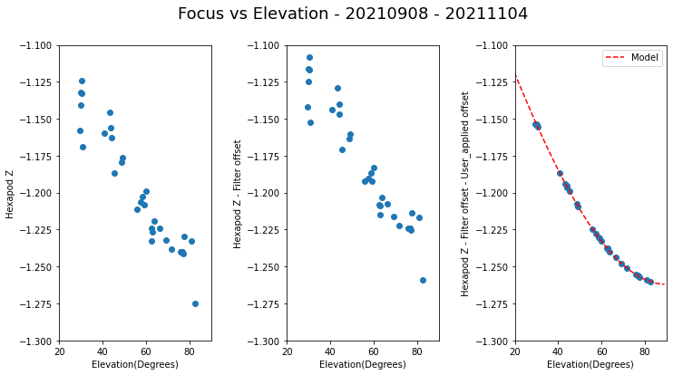

```python
fig = plt.figure(figsize = (12,6))
plt.suptitle(f"Focus vs Elevation - 20210908 - 20211104", fontsize = 18)
plt.subplots_adjust(wspace=0.5)
plt.subplot(1,3,1)
plt.scatter(els, poss)
plt.xlabel("Elevation(Degrees)")
plt.ylabel("Hexapod Z")
plt.ylim(-1.30, -1.10)
plt.xlim(20.0, 90.0)

plt.subplot(1,3,2)
plt.scatter(els, poss-filt)
plt.xlabel("Elevation(Degrees)")
plt.ylabel("Hexapod Z - Filter offset")
plt.ylim(-1.30, -1.10)
plt.xlim(20.0, 90.0)

# Plot the focus ve elevation model
poly_z = -0.217
poly_int = -1.045
xplot = np.linspace(5.5, 89.0, 100)
yplot = poly_int + poly_z * np.cos(np.radians(90.0 - xplot))
plt.subplot(1,3,3)
plt.scatter(els, poss-filt-user)
plt.plot(xplot, yplot, ls = '--', color = 'red', label = 'Model')
plt.xlabel("Elevation(Degrees)")
plt.ylabel("Hexapod Z - Filter offset - User_applied offset")
plt.ylim(-1.30, -1.10)
plt.xlim(20.0, 90.0)
plt.legend()

plt.savefig(f"/project/cslage/AuxTel/efd_temp/Focus_vs_Elevation_1_08Dec21.pdf")
```

In the plot above, the left hand panel is the extracted data of the Hexapod-Z setting that gave the best focus as a function of elevation. The center panel is the same data with the filter offset removed. The filters have slightly different thicknesses and this needs to be compensated for. Note that this is only a very small adjustment. In the right hand panel, the user applied offset has been subtracted. The user applied offset is what was determined necessary by the CWFS algorithm, so when this is subtracted, you recover the focus offset model that was used during the observations. The red line is not a fit, but is the model that was in the code, basically:

Z-offset = poly_int + poly_z * cos(90.0 - elevation)

The fact that this fits the data shows that we have successfully recovered the model that was used.

```python
# These functions are used to fit the data
from scipy.optimize import curve_fit

def func(X, intercept, slopeE, slopeT):
    # A linear fit to T and el
    el, T = X
    return (intercept + slopeE * el + slopeT * T)

def func_cos(X, intercept, slopeE, slopeT):
    # A linear fit to T and cos(90-el)
    el, T = X
    return (intercept + slopeE * np.cos(np.radians(90.0 - el)) + slopeT * T)


def chiSquared(myFunc, els, temps, vals, sigma):
    # Chi squared per DOF for the given model
    chiSq = 0.0
    intercept, slopeE, slopeT = fit
    model = myFunc((els, temps), intercept, slopeE, slopeT)
    for i, val in enumerate(vals):
        chiSq += (model[i] - val)**2 / sigma**2
    # Degrees of freedom are number of data points - number of fit parameters
    dof = len(vals) - 3
    return chiSq / dof
```

We want to see which model fits the data best. We have two models, a linear fit to elevation, and a linear fit to cos(90-el). We also have four temperatures, t_air, which is the air temperature in the dome, t_truss, which is the temperature on the truss supporting the secondary, t_m2, which is the temperatue at the M2 mirror, and t_ext, which is the outside air temperature at the weather station. We calculate the chi-squared of the fit to see which of these 8 fits the data best. We find that the linear fit and t_air give the best fit. Note that the fit to temperature is always linear.

```python
names = ['Air', 'Truss', 'M2', 'Ext']
for i, temps in enumerate([temp_airs, temp_trusss, temp_m2s, temp_exts]):
    p0 = -1.2, -2E-3, 5E-3
    fit, covs = curve_fit(func, (els, temps), poss - filt, p0)
    intercept, slopeE, slopeT = fit
    print(f"Linear fit, {names[i]}: ChiSquared = \
    {chiSquared(func, els, temps, poss - filt, 0.01)}")
    fit, covs = curve_fit(func_cos, (els, temps), poss - filt, p0)
    intercept, slopeE, slopeT = fit
    print(f"Cosine fit, {names[i]}: ChiSquared = \
    {chiSquared(func_cos, els, temps, poss - filt, 0.01)}")
```

```
Linear fit, Air: ChiSquared =     0.7116720272235075
Cosine fit, Air: ChiSquared =     1.135234900341103
Linear fit, Truss: ChiSquared =     0.7451148422319153
Cosine fit, Truss: ChiSquared =     1.0932994383842425
Linear fit, M2: ChiSquared =     0.8827934687478702
Cosine fit, M2: ChiSquared =     1.2527968305758355
Linear fit, Ext: ChiSquared =     1.114490346061319
Cosine fit, Ext: ChiSquared =     1.5503835688477101
```

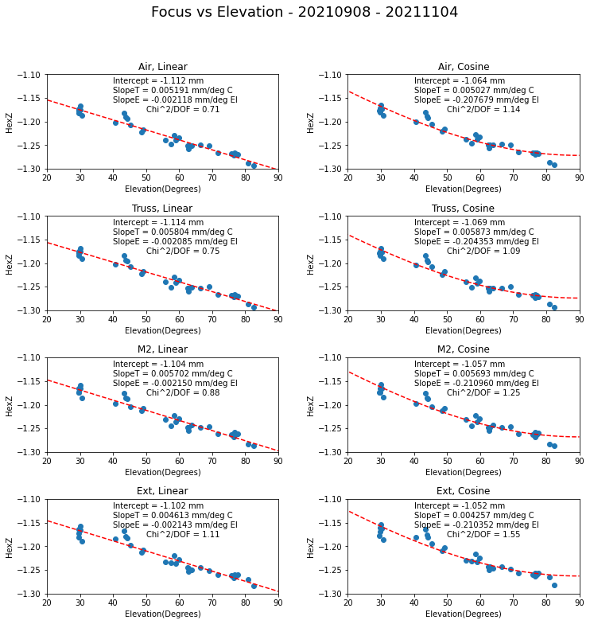

```python
# Now we plot the 8 fits.  To get it on a 2D plot, we subtract off the temperature
# compensation and plot focus vs elevation.

fig = plt.figure(figsize = (12,12))
plt.suptitle(f"Focus vs Elevation - 20210908 - 20211104", fontsize = 18)
plt.subplots_adjust(wspace=0.3, hspace=0.5)

for i, temps in enumerate([temp_airs, temp_trusss, temp_m2s, temp_exts]):
    p0 = -1.2, -2E-3, 5E-3
    fit, covs = curve_fit(func, (els, temps), poss - filt, p0)
    intercept, slopeE, slopeT = fit
    chi2 = chiSquared(func, els, temps, poss - filt, 0.01)

    plt.subplot(4,2,2*i+1)
    plt.title(f"{names[i]}, Linear", fontsize=12)
    plt.scatter(els, poss - filt - slopeT * temps)
    xplot = np.linspace(0,90,100)
    yplot = intercept + slopeE * xplot
    plt.plot(xplot, yplot, ls = '--', color = 'red')
    plt.ylim(-1.30, -1.10)
    plt.xlim(20.0, 90.0)
    plt.xlabel("Elevation(Degrees)")
    plt.ylabel("HexZ")
    plt.text(40.0, -1.12, f"Intercept = {intercept:0.3f} mm")
    plt.text(40.0, -1.14, f"SlopeT = {slopeT:0.6f} mm/deg C")
    plt.text(40.0, -1.16, f"SlopeE = {slopeE:0.6f} mm/deg El")
    plt.text(50.0, -1.18, f"Chi^2/DOF = {chi2:0.2f}")

    fit, covs = curve_fit(func_cos, (els, temps), poss - filt, p0)
    intercept, slopeE, slopeT = fit
    chi2 = chiSquared(func_cos, els, temps, poss - filt, 0.01)
    plt.subplot(4,2,2*i+2)
    plt.title(f"{names[i]}, Cosine", fontsize=12)
    plt.scatter(els, poss - filt - slopeT * temps)
    xplot = np.linspace(0,90,100)
    yplot = intercept + slopeE * np.cos(np.radians(90.0 - xplot))
    plt.plot(xplot, yplot, ls = '--', color = 'red')
    plt.ylim(-1.30, -1.10)
    plt.xlim(20.0, 90.0)
    plt.xlabel("Elevation(Degrees)")
    plt.ylabel("HexZ")
    plt.text(40.0, -1.12, f"Intercept = {intercept:0.3f} mm")
    plt.text(40.0, -1.14, f"SlopeT = {slopeT:0.6f} mm/deg C")
    plt.text(40.0, -1.16, f"SlopeE = {slopeE:0.6f} mm/deg El")
    plt.text(50.0, -1.18, f"Chi^2/DOF = {chi2:0.2f}")
plt.savefig(f"/project/cslage/AuxTel/efd_temp/Focus_vs_Elevation_Models_13Dec21.pdf")
```

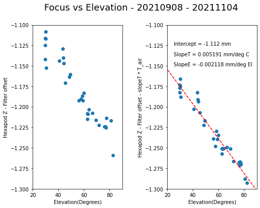

```python
# Now we plot the best fit to show the improvement
temps = temp_airs
fit, covs = curve_fit(func, (els, temps), poss - filt, p0)
intercept, slopeE, slopeT = fit

fig = plt.figure(figsize = (8,6))
plt.suptitle(f"Focus vs Elevation - 20210908 - 20211104", fontsize = 18)
plt.subplots_adjust(wspace=0.5)
plt.subplot(1,2,1)
plt.scatter(els, poss - filt)
plt.xlabel("Elevation(Degrees)")
plt.ylabel("Hexapod Z - Filter offset")
plt.ylim(-1.30, -1.10)
plt.xlim(20.0, 90.0)
plt.subplot(1,2,2)
plt.scatter(els, poss - filt - slopeT * temps)
xplot = np.linspace(0,90,100)
yplot = intercept + slopeE * xplot
plt.plot(xplot, yplot, ls = '--', color = 'red')
plt.ylim(-1.30, -1.10)
plt.xlim(20.0, 90.0)
plt.xlabel("Elevation(Degrees)")
plt.ylabel("Hexapod Z - Filter offset - slopeT * T_air")
plt.text(25.0, -1.125, f"Intercept = {intercept:0.3f} mm")
plt.text(25.0, -1.1375, f"SlopeT = {slopeT:0.6f} mm/deg C")
plt.text(25.0, -1.15, f"SlopeE = {slopeE:0.6f} mm/deg El")
plt.savefig(f"/project/cslage/AuxTel/efd_temp/Focus_vs_Elevation_5_08Dec21.pdf")
```

This plot shows the improvement due to the temperature compensation. The left hand plot is without including temperature. The right hand plot is the best fit model, with the temperature compensation included. You can see that the scatter is significantly reduced.